# STAT545-hw01-wynes-chris

## Learning how to use rmarkdown and Github

## Overview

**For my homework, I have created a readme document to introduce myself to the class**

#### Seth Wynes

*I am a PhD student in the [Department of Geography](http://www.geog.ubc.ca/), studying climate change mitigation. I’m originally from Ontario but I’m loving this beautiful province!*

## Useful links

- Stats 545 homepage
- [Stats 545 syllabus](http://stat545.com/syllabus.html)
- [Stack Overflow](https://stackoverflow.com/)

They say a picture is worth 1000 words - but have you ever considered how many lines of code that might convert to? Regardless of the answer, Markdown makes it easy include pictures of all sorts into your document. Don’t believe me? See the source code yourself!

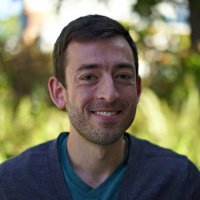

## Further Reading and Resources

Still confused? Want to have some other resources to look at other than the source code of this readme.md file? Here are a few additional guides that you can reference as you complete your own readme.md file and beyond:

- [RStudio Markdown Cheat Sheet](https://www.rstudio.com/wp-content/uploads/2015/02/rmarkdown-cheatsheet.pdf)
- [Github Markdown Cheat Sheet](https://github.com/adam-p/markdown-here/wiki/Markdown-Cheatsheet)
- [How to Set Up Sublime Text For Markdown Editing](http://plaintext-productivity.net/2-04-how-to-set-up-sublime-text-for-markdown-editing.html)
- [Markdown Syntax Summary by John Gruber, Creator of Markdown Format](https://daringfireball.net/projects/markdown/syntax)